# HIGH LEVEL FLOW OF PROJECT

## Problem 1: Categorize merchants

1. Data Preparation
2. Data Wrangling
3. Data Analysis - RFM Analysis (Recency, Frequency, Monetary)
4. Categorize merchants by RFM score
5. Train Models: K-Means & HDBScan Clustering
6. Match clusters with segments made by RFM score

## Problem 2: Detect and predict churn

1. Identify churn
2. Resampling data
3. Train model: Logistic Regression
4. Improve the model using hyperparameter tuning
5. Predict churn for active user data

## Problem 1

## 1. Data Preparation

```python
# Load libraries
import numpy as np
import pandas as pd
import matplotlib.pyplot as plt
%matplotlib inline
import datetime as dt
from scipy import stats
import jenkspy
import seaborn as sns
import warnings
warnings.filterwarnings("ignore")
```

```python
# Load data
df = pd.read_csv('takehome_ds_written.csv')
df
```

|  | Unnamed: 0 | merchant | time | amount_usd_in_cents |
| --- | --- | --- | --- | --- |
| 0 | 1 | faa029c6b0 | 2034-06-17 23:34:14 | 6349 |
| 1 | 2 | ed7a7d91aa | 2034-12-27 00:40:38 | 3854 |
| 2 | 3 | 5608f200cf | 2034-04-30 01:29:42 | 789 |
| 3 | 4 | 15b1a0d61e | 2034-09-16 01:06:23 | 4452 |
| 4 | 5 | 4770051790 | 2034-07-22 16:21:42 | 20203 |
| ... | ... | ... | ... | ... |
| 1513714 | 1513715 | 72d37bedbf | 2034-06-21 13:47:51 | 5274 |
| 1513715 | 1513716 | 5608f200cf | 2034-04-20 02:23:59 | 754 |
| 1513716 | 1513717 | fcbd1dae68 | 2033-09-19 14:02:33 | 13203 |
| 1513717 | 1513718 | 9843e52410 | 2034-12-28 20:07:59 | 4845 |
| 1513718 | 1513719 | 32acddd6cc | 2034-08-23 09:07:07 | 3862 |

1513719 rows × 4 columns

```python
# Get data types
df.info()
```

```
<class 'pandas.core.frame.DataFrame'>
RangeIndex: 1513719 entries, 0 to 1513718
Data columns (total 4 columns):
 #   Column               Non-Null Count    Dtype
---  ------               --------------    -----
 0   Unnamed: 0           1513719 non-null  int64
 1   merchant             1513719 non-null  object
 2   time                 1513719 non-null  object
 3   amount_usd_in_cents  1513719 non-null  int64
dtypes: int64(2), object(2)
memory usage: 46.2+ MB
```

```python
# Check the number of rows, columns
df.shape
```

```
(1513719, 4)
```

## 2. Data Wrangling

### Data Cleaning

#### Check missing values of each column.

```python
df.isnull().sum()
```

```
Unnamed: 0             0
merchant               0
time                   0
amount_usd_in_cents    0
dtype: int64
```

There is no null values

#### Drop unwanted column

```python
# Drop unwanted column
df.drop(df.columns[0], axis=1, inplace = True)
df.head()
```

|  | merchant | time | amount_usd_in_cents |
| --- | --- | --- | --- |
| 0 | faa029c6b0 | 2034-06-17 23:34:14 | 6349 |
| 1 | ed7a7d91aa | 2034-12-27 00:40:38 | 3854 |
| 2 | 5608f200cf | 2034-04-30 01:29:42 | 789 |
| 3 | 15b1a0d61e | 2034-09-16 01:06:23 | 4452 |
| 4 | 4770051790 | 2034-07-22 16:21:42 | 20203 |

#### Check negative value in amount

```python
df[df.amount_usd_in_cents<0]
```

[output not shown]

There is no negative amount

#### Check and drop duplicate rows

```python
# Selecting duplicate based on all columns
duplicate = df[df.duplicated()]
print("Duplicate Rows :")
duplicate
```

```
Duplicate Rows :
```

|  | merchant | time | amount_usd_in_cents |
| --- | --- | --- | --- |
| 103484 | 654930c922 | 2033-01-11 22:12:09 | 5599 |
| 111486 | 93c247a1fc | 2034-06-12 03:30:29 | 13051 |
| 139347 | 7be05385c5 | 2033-10-02 12:43:34 | 3886 |
| 148500 | 44ee3ec72c | 2034-10-21 04:55:01 | 47841 |
| 174523 | ded17864fa | 2033-10-12 22:46:53 | 1167 |
| ... | ... | ... | ... |
| 1493102 | 0a309e574d | 2034-05-26 14:50:31 | 4636 |
| 1496157 | 44ee3ec72c | 2034-10-21 05:54:18 | 47841 |
| 1496750 | ce61387781 | 2033-07-20 03:33:16 | 39241 |
| 1506688 | 2a1cf4ff5b | 2034-10-01 16:05:42 | 8406 |
| 1511283 | 82897075ed | 2033-11-19 16:51:45 | 20724 |

218 rows × 3 columns

```python
# Print the number of duplicate observations.
print('The number of duplicate rows:',df.duplicated().sum())
```

```
The number of duplicate rows: 218
```

```python
#Drop Duplicate Observations.
df.drop_duplicates(inplace=True)
```

```python
print("Re-checking the number of duplicate observations:")
df.duplicated().sum()
```

```
Re-checking the number of duplicate observations:
```

```
0
```

### Adding month and date column

```python
# Convert time column to datetime data
df['time'] = pd.to_datetime(df['time'])

# Create month and year columns
import datetime
df['month'] = df.time.dt.strftime('%Y-%m')
df['date'] = df.time.dt.strftime('%Y-%m-%d')
df
```

|  | merchant | time | amount_usd_in_cents | month | date |
| --- | --- | --- | --- | --- | --- |
| 0 | faa029c6b0 | 2034-06-17 23:34:14 | 6349 | 2034-06 | 2034-06-17 |
| 1 | ed7a7d91aa | 2034-12-27 00:40:38 | 3854 | 2034-12 | 2034-12-27 |
| 2 | 5608f200cf | 2034-04-30 01:29:42 | 789 | 2034-04 | 2034-04-30 |
| 3 | 15b1a0d61e | 2034-09-16 01:06:23 | 4452 | 2034-09 | 2034-09-16 |
| 4 | 4770051790 | 2034-07-22 16:21:42 | 20203 | 2034-07 | 2034-07-22 |
| ... | ... | ... | ... | ... | ... |
| 1513714 | 72d37bedbf | 2034-06-21 13:47:51 | 5274 | 2034-06 | 2034-06-21 |
| 1513715 | 5608f200cf | 2034-04-20 02:23:59 | 754 | 2034-04 | 2034-04-20 |
| 1513716 | fcbd1dae68 | 2033-09-19 14:02:33 | 13203 | 2033-09 | 2033-09-19 |
| 1513717 | 9843e52410 | 2034-12-28 20:07:59 | 4845 | 2034-12 | 2034-12-28 |
| 1513718 | 32acddd6cc | 2034-08-23 09:07:07 | 3862 | 2034-08 | 2034-08-23 |

1513501 rows × 5 columns

```python
# Turn off scientific notation
pd.options.display.float_format = '{:.2f}'.format
```

## 3. Data Analysis

## RFM SEGMENTATION ANALYSIS (RECENCY, FREQUENCY, MONETARY)

### RFM Segmentation

RFM analysis is a data driven customer behavior segmentation technique. RFM stands for recency, frequency, and monetary value.

- Recency: days since last transaction
- Frequency: counts of all transactions
- Monetary: total money transacted

As the data we have only contains merchant id, transaction amount and date transacted, RFM analysis perfectly capitalizes on all those data points to segment customers based on when their last purchase was, how often they’ve purchased in the past, and how much they’ve spent.

### Benefits of RFM Analysis

Conducting an RFM analysis on customer base and sending personalized campaigns to high value targets results in favorable benefits

- Personalization: By creating effective customer segments, Stripe can create relevant, personalized offers.
- Improve Conversion Rates: Personalized offers will yield higher conversion rates because customers are engaging with products they care about.
- Improve unit economics
- Increase revenue and profits

Assumptions:

- Current time is 01/01/2035
- There is no fraud transaction
- All transactions have been processed successfully (not declined or refunded)
- All transactions have been processed only through Stripe (not imported by other payment systems)

```python
# Date of last transaction per merchant (Recency)
last = df.groupby(['merchant']).last().reset_index()
last = last.rename(columns={'date':'last_transaction_date'})
```

```python
# Frequency - the total number of transactions per merchant
d = pd.DataFrame(df['merchant'].value_counts().reset_index())
d = d.rename(columns={'index': 'merchant', 'merchant':'number_of_transactions'})
```

```python
dff = df.groupby(['merchant'])['amount_usd_in_cents'].sum().reset_index()
dff = dff.rename(columns={'amount_usd_in_cents': 'sum_amount'})
```

```python
# Merge tables to create an RFM table for further analysis
df_merchant = pd.merge(dff,last)
df_merchant = pd.merge(d,df_merchant)
df_merchant.drop(columns= ['amount_usd_in_cents'], inplace=True)
df_merchant
```

|  | merchant | number_of_transactions | sum_amount | time | month | last_transaction_date |
| --- | --- | --- | --- | --- | --- | --- |
| 0 | 5608f200cf | 25507 | 20907471 | 2034-04-20 02:23:59 | 2034-04 | 2034-04-20 |
| 1 | 53b3fbeae2 | 12178 | 60733740 | 2034-07-20 20:46:24 | 2034-07 | 2034-07-20 |
| 2 | 1ddaea9838 | 12042 | 41443545 | 2034-06-05 21:34:16 | 2034-06 | 2034-06-05 |
| 3 | 89e2d29885 | 11969 | 18054500 | 2034-11-17 15:32:24 | 2034-11 | 2034-11-17 |
| 4 | 654930c922 | 11191 | 150931806 | 2033-01-12 11:01:04 | 2033-01 | 2033-01-12 |
| ... | ... | ... | ... | ... | ... | ... |
| 14346 | 3839c43c25 | 1 | 93980 | 2033-01-12 02:29:43 | 2033-01 | 2033-01-12 |
| 14347 | 5cdc7cd9f5 | 1 | 23906 | 2034-03-15 19:58:03 | 2034-03 | 2034-03-15 |
| 14348 | 1718d01b43 | 1 | 48197 | 2033-01-08 18:01:18 | 2033-01 | 2033-01-08 |
| 14349 | 4cf644502f | 1 | 17536 | 2033-02-15 01:53:54 | 2033-02 | 2033-02-15 |
| 14350 | 314ea3d710 | 1 | 2068 | 2034-08-29 01:19:37 | 2034-08 | 2034-08-29 |

14351 rows × 6 columns

```python
# Create RFM (recency, frequency, monetary) table by merging the tables above
merchant = pd.merge(dff,last)
merchant = pd.merge(d,merchant)
merchant.drop(columns= ['amount_usd_in_cents','time'], inplace=True)
merchant = merchant.rename(columns={'number_of_transactions': 'frequency', 'sum_amount':'monetary'})
merchant
```

|  | merchant | frequency | monetary | month | last_transaction_date |
| --- | --- | --- | --- | --- | --- |
| 0 | 5608f200cf | 25507 | 20907471 | 2034-04 | 2034-04-20 |
| 1 | 53b3fbeae2 | 12178 | 60733740 | 2034-07 | 2034-07-20 |
| 2 | 1ddaea9838 | 12042 | 41443545 | 2034-06 | 2034-06-05 |
| 3 | 89e2d29885 | 11969 | 18054500 | 2034-11 | 2034-11-17 |
| 4 | 654930c922 | 11191 | 150931806 | 2033-01 | 2033-01-12 |
| ... | ... | ... | ... | ... | ... |
| 14346 | 3839c43c25 | 1 | 93980 | 2033-01 | 2033-01-12 |
| 14347 | 5cdc7cd9f5 | 1 | 23906 | 2034-03 | 2034-03-15 |
| 14348 | 1718d01b43 | 1 | 48197 | 2033-01 | 2033-01-08 |
| 14349 | 4cf644502f | 1 | 17536 | 2033-02 | 2033-02-15 |
| 14350 | 314ea3d710 | 1 | 2068 | 2034-08 | 2034-08-29 |

14351 rows × 5 columns

```python
# Create recency column by substracting today month and last_transaction_month
from datetime import datetime
today = datetime.strptime('2035-01-01','%Y-%m-%d')
merchant['last_transaction_date']= pd.to_datetime(merchant['last_transaction_date'])
merchant['recency'] = today - merchant['last_transaction_date']
merchant
```

|  | merchant | frequency | monetary | month | last_transaction_date | recency |
| --- | --- | --- | --- | --- | --- | --- |
| 0 | 5608f200cf | 25507 | 20907471 | 2034-04 | 2034-04-20 | 256 days |
| 1 | 53b3fbeae2 | 12178 | 60733740 | 2034-07 | 2034-07-20 | 165 days |
| 2 | 1ddaea9838 | 12042 | 41443545 | 2034-06 | 2034-06-05 | 210 days |
| 3 | 89e2d29885 | 11969 | 18054500 | 2034-11 | 2034-11-17 | 45 days |
| 4 | 654930c922 | 11191 | 150931806 | 2033-01 | 2033-01-12 | 719 days |
| ... | ... | ... | ... | ... | ... | ... |
| 14346 | 3839c43c25 | 1 | 93980 | 2033-01 | 2033-01-12 | 719 days |
| 14347 | 5cdc7cd9f5 | 1 | 23906 | 2034-03 | 2034-03-15 | 292 days |
| 14348 | 1718d01b43 | 1 | 48197 | 2033-01 | 2033-01-08 | 723 days |
| 14349 | 4cf644502f | 1 | 17536 | 2033-02 | 2033-02-15 | 685 days |
| 14350 | 314ea3d710 | 1 | 2068 | 2034-08 | 2034-08-29 | 125 days |

14351 rows × 6 columns

### Determine the optimal number of splits/scores for recency, frequency and monetary

#### Identify the optimal number of classes by looking at goodness_of_variance_fit

```python
# Create goodness_of_variance_fit function
def goodness_of_variance_fit(array, classes):
    # get the break points
    classes = jenkspy.jenks_breaks(array, nb_class=classes)
# do the actual classification
    classified = np.array([classify(i, classes) for i in array])
# max value of zones
    maxz = max(classified)
# nested list of zone indices
    zone_indices = [[idx for idx, val in enumerate(classified) if zone + 1 == val] for zone in range(maxz)]
# sum of squared deviations from array mean
    sdam = np.sum((array - array.mean()) ** 2)
# sorted polygon stats
    array_sort = [np.array([array[index] for index in zone]) for zone in zone_indices]
# sum of squared deviations of class means
    sdcm = sum([np.sum((classified - classified.mean()) ** 2) for classified in array_sort])
# goodness of variance fit
    gvf = (sdam - sdcm) / sdam
    return gvf
def classify(value, breaks):
    for i in range(1, len(breaks)):
        if value < breaks[i]:
            return i
    return len(breaks) - 1
```

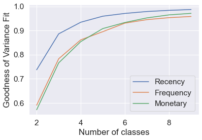

```python
#Plot the goodness of variance fit against the number of classes:
my_dict = {}
for col in rfm.columns[:3]:
    results = []
    for i in range(2, 10):
        results.append(goodness_of_variance_fit(rfm[col], i))
    my_dict[col] = results
plt.plot(range(2, 10), my_dict['recency'], label='Recency')
plt.plot(range(2, 10), my_dict['frequency'], label='Frequency')
plt.plot(range(2, 10), my_dict['monetary'], label='Monetary')
plt.xlabel('Number of classes')
plt.ylabel('Goodness of Variance Fit')
plt.legend(loc='best')
plt.show()
```

This method is similar to the elbow plot in K-Means Clustering. We can spot that 4 is optimal. So here I will use quartile to split the data

Now we will score each customer according to their position.

There are many ways to do this but here we will use quartiles (divide the data by 4 as the optimal split) as it is the easiest and most understandable way

To create RFM scores, quartile analysis can help assign scores based on relative performance. The method is taking the total number of customers divided by four. Each quartile will give a score, 1 through 4. Next, give each quartile a score reflective of the position.

- First Quartile: 1
- Second Quartile: 2
- Third Quartile: 3
- Fourth Quartile: 4

```python
# Calculate quartile and percentile to get RFM scores
merchant['r_percentile'] = merchant['recency'].rank(pct=True,ascending=False)
merchant['r_score'] = pd.qcut(merchant['r_percentile'], 4, labels=range(4,0,-1))
merchant['f_percentile'] = merchant['frequency'].rank(pct=True,ascending=True)
merchant['f_score'] = pd.qcut(merchant['f_percentile'], 4, labels=range(4,0,-1))
merchant['m_percentile'] = merchant['monetary'].rank(pct=True,ascending=True)
merchant['m_score'] = pd.qcut(merchant['m_percentile'], 4, labels=range(4,0,-1))

merchant
```

|  | merchant | frequency | monetary | month | last_transaction_date | recency | r_percentile | r_score | f_percentile | f_score | m_percentile | m_score |
| --- | --- | --- | --- | --- | --- | --- | --- | --- | --- | --- | --- | --- |
| 0 | 5608f200cf | 25507 | 20907471 | 2034-04 | 2034-04-20 | 256 days | 0.39 | 3 | 1.00 | 1 | 0.99 | 1 |
| 1 | 53b3fbeae2 | 12178 | 60733740 | 2034-07 | 2034-07-20 | 165 days | 0.54 | 2 | 1.00 | 1 | 1.00 | 1 |
| 2 | 1ddaea9838 | 12042 | 41443545 | 2034-06 | 2034-06-05 | 210 days | 0.47 | 3 | 1.00 | 1 | 1.00 | 1 |
| 3 | 89e2d29885 | 11969 | 18054500 | 2034-11 | 2034-11-17 | 45 days | 0.82 | 1 | 1.00 | 1 | 0.98 | 1 |
| 4 | 654930c922 | 11191 | 150931806 | 2033-01 | 2033-01-12 | 719 days | 0.00 | 4 | 1.00 | 1 | 1.00 | 1 |
| ... | ... | ... | ... | ... | ... | ... | ... | ... | ... | ... | ... | ... |
| 14346 | 3839c43c25 | 1 | 93980 | 2033-01 | 2033-01-12 | 719 days | 0.00 | 4 | 0.06 | 4 | 0.41 | 3 |
| 14347 | 5cdc7cd9f5 | 1 | 23906 | 2034-03 | 2034-03-15 | 292 days | 0.34 | 3 | 0.06 | 4 | 0.18 | 4 |
| 14348 | 1718d01b43 | 1 | 48197 | 2033-01 | 2033-01-08 | 723 days | 0.00 | 4 | 0.06 | 4 | 0.30 | 3 |
| 14349 | 4cf644502f | 1 | 17536 | 2033-02 | 2033-02-15 | 685 days | 0.01 | 4 | 0.06 | 4 | 0.14 | 4 |
| 14350 | 314ea3d710 | 1 | 2068 | 2034-08 | 2034-08-29 | 125 days | 0.62 | 2 | 0.06 | 4 | 0.01 | 4 |

14351 rows × 12 columns

Current timeframe: end of 2034, beginning of 2035

- Based on quartile, recency, frequency and monetary each is given a score ranking from 1 to 4.
- For example, recency 1 : merchant made the last transaction within the last 3 months 2 : merchant made the last transaction within the last 6 months 3 : merchant made the last transaction within the last 12 months 4 : merchant made the last transaction within the last 24 months

The resulting table has Recency, Frequency and Monetary columns, along with the percentile and quartile for each value

```python
# Convert recency to integer
merchant['recency'] = merchant['recency'].dt.days.astype(int)
```

```python
# Values the data was partitioned on based on quartiles
r_quarters = merchant['recency'].quantile(q=[0.0, 0.25,0.5,0.75, 1])
f_quarters = merchant['frequency'].quantile(q=[0.0, 0.25,0.5,0.75, 1]).to_list()
m_quarters = merchant['monetary'].quantile(q=[0.0, 0.25,0.5,0.75, 1]).to_list()
quartile_spread = pd.DataFrame(list(zip(r_quarters, f_quarters, m_quarters)),
                      columns=['Q_Recency','Q_Frequency', 'Q_Monetary'],
                     index = ['min', '0.25','0.50','0.75', 'max'])
quartile_spread
```

|  | Q_Recency | Q_Frequency | Q_Monetary |
| --- | --- | --- | --- |
| min | 1.00 | 1.00 | 201.00 |
| 0.25 | 71.00 | 3.00 | 36263.00 |
| 0.50 | 190.00 | 11.00 | 160262.00 |
| 0.75 | 364.00 | 45.00 | 823099.50 |
| max | 729.00 | 25507.00 | 233045139.00 |

## 4. Categorize merchants by RFM score

We will categorize merchants by RFM score. RFM score is formed by concating recency, frequency and monetary score. The score of each criteria is based on quartile formula mentioned above

```python
# Concat the three columns to create rfm_score column
merchant['rfm_score'] = merchant['r_score'].astype(str) + merchant['f_score'].astype(str) + merchant['m_score'].astype(str)
merchant
```

|  | merchant | frequency | monetary | month | last_transaction_date | recency | r_percentile | r_score | f_percentile | f_score | m_percentile | m_score | rfm_score |
| --- | --- | --- | --- | --- | --- | --- | --- | --- | --- | --- | --- | --- | --- |
| 0 | 5608f200cf | 25507 | 20907471 | 2034-04 | 2034-04-20 | 256 | 0.39 | 3 | 1.00 | 1 | 0.99 | 1 | 311 |
| 1 | 53b3fbeae2 | 12178 | 60733740 | 2034-07 | 2034-07-20 | 165 | 0.54 | 2 | 1.00 | 1 | 1.00 | 1 | 211 |
| 2 | 1ddaea9838 | 12042 | 41443545 | 2034-06 | 2034-06-05 | 210 | 0.47 | 3 | 1.00 | 1 | 1.00 | 1 | 311 |
| 3 | 89e2d29885 | 11969 | 18054500 | 2034-11 | 2034-11-17 | 45 | 0.82 | 1 | 1.00 | 1 | 0.98 | 1 | 111 |
| 4 | 654930c922 | 11191 | 150931806 | 2033-01 | 2033-01-12 | 719 | 0.00 | 4 | 1.00 | 1 | 1.00 | 1 | 411 |
| ... | ... | ... | ... | ... | ... | ... | ... | ... | ... | ... | ... | ... | ... |
| 14346 | 3839c43c25 | 1 | 93980 | 2033-01 | 2033-01-12 | 719 | 0.00 | 4 | 0.06 | 4 | 0.41 | 3 | 443 |
| 14347 | 5cdc7cd9f5 | 1 | 23906 | 2034-03 | 2034-03-15 | 292 | 0.34 | 3 | 0.06 | 4 | 0.18 | 4 | 344 |
| 14348 | 1718d01b43 | 1 | 48197 | 2033-01 | 2033-01-08 | 723 | 0.00 | 4 | 0.06 | 4 | 0.30 | 3 | 443 |
| 14349 | 4cf644502f | 1 | 17536 | 2033-02 | 2033-02-15 | 685 | 0.01 | 4 | 0.06 | 4 | 0.14 | 4 | 444 |
| 14350 | 314ea3d710 | 1 | 2068 | 2034-08 | 2034-08-29 | 125 | 0.62 | 2 | 0.06 | 4 | 0.01 | 4 | 244 |

14351 rows × 13 columns

The most high value customers are those in segment 111

### Visualize the result

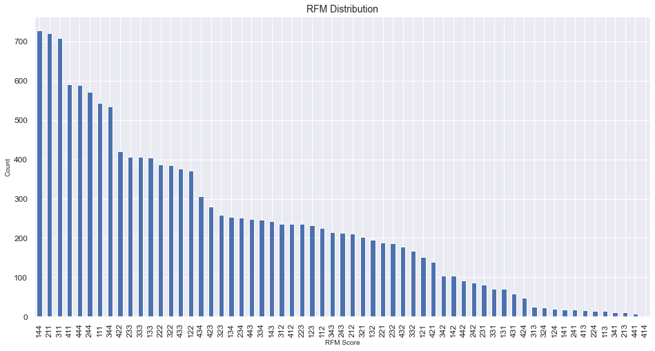

```python
# Visualize the score distribution
ax = merchant['rfm_score'].value_counts().plot(kind='bar', figsize=(16, 8), fontsize=12)
ax.set_title('RFM Distribution', fontsize = 14)
ax.set_xlabel("RFM Score", fontsize=10)
ax.set_ylabel("Count", fontsize=10)
plt.show()
```

#### Comments

- The largest segment is one that has recently transacted within the last 3 months but their transaction amount and frequency are low. These could be new customers that are not familiar with the platform
- Our second, third and fourth largest segments are made up of our best valuable customers in terms of frequency and monetary. However, their last transaction was within 6 months to 2 years ago. This indicate that a large number of high value customers are churn and might churn quickly. Therefore, management should have proper strategies to get them back.

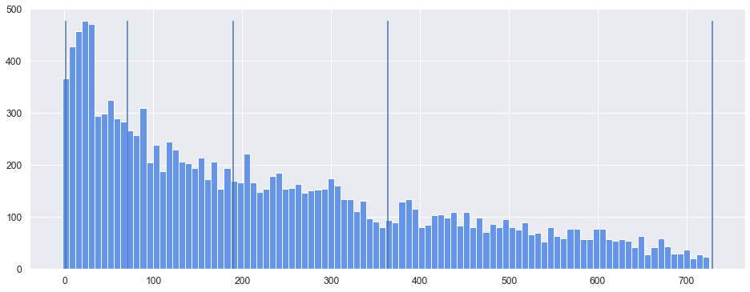

```python
# Visualize the density of the segments by plotting a histogram with our partitions
plt.figure(figsize = (16,6))
hist = plt.hist(merchant['recency'], bins=100, align='left', color='cornflowerblue')
for q in r_quarters:
    plt.vlines(q, ymin=0, ymax = max(hist[0]))
```

The partitions split each part not equally. We can try using Jenks Natural Breaks to partition our data instead of quartiles.

```python
# Use Jenks Natural Breaks to partition our data instead of quartiles
r_breaks = jenkspy.jenks_breaks(merchant['recency'], nb_class=4)
f_breaks = jenkspy.jenks_breaks(merchant['frequency'], nb_class=4)
m_breaks = jenkspy.jenks_breaks(merchant['monetary'], nb_class=4)
jenks_spread = pd.DataFrame(list(zip(r_breaks, f_breaks, m_breaks)),
                      columns=['J_Recency','J_Frequency', 'J_Monetary'],
                     index = ['min', '0.25','0.50','0.75', 'max'])
jenks_spread
```

|  | J_Recency | J_Frequency | J_Monetary |
| --- | --- | --- | --- |
| min | 1.00 | 1.00 | 201.00 |
| 0.25 | 133.00 | 715.00 | 8019293.00 |
| 0.50 | 294.00 | 2859.00 | 35923369.00 |
| 0.75 | 481.00 | 7172.00 | 110302095.00 |
| max | 729.00 | 25507.00 | 233045139.00 |

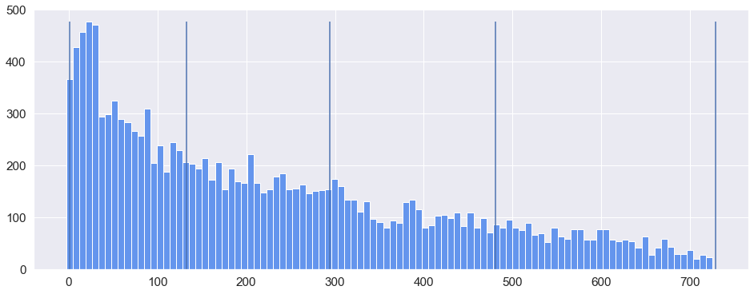

```python
plt.figure(figsize = (16,6))
hist = plt.hist(merchant['recency'], bins=100, align='left', color='cornflowerblue')
for b in r_breaks:
    plt.vlines(b, ymin=0, ymax = max(hist[0]))
```

The partitions here look better and more equally distributed

```python
# Compare partition tables side by side
dfp = pd.concat([quartile_spread, jenks_spread], axis=1)
cols = ['Q_Recency', 'J_Recency','Q_Frequency', 'J_Frequency','Q_Monetary', 'J_Monetary']
dfp[cols]
```

|  | Q_Recency | J_Recency | Q_Frequency | J_Frequency | Q_Monetary | J_Monetary |
| --- | --- | --- | --- | --- | --- | --- |
| min | 1.00 | 1.00 | 1.00 | 1.00 | 201.00 | 201.00 |
| 0.25 | 71.00 | 133.00 | 3.00 | 715.00 | 36263.00 | 8019293.00 |
| 0.50 | 190.00 | 294.00 | 11.00 | 2859.00 | 160262.00 | 35923369.00 |
| 0.75 | 364.00 | 481.00 | 45.00 | 7172.00 | 823099.50 | 110302095.00 |
| max | 729.00 | 729.00 | 25507.00 | 25507.00 | 233045139.00 | 233045139.00 |

```python
# Get rfm data that only contains recency, frequency, monetary
rfm = merchant[['recency','frequency','monetary']]
rfm
```

|  | recency | frequency | monetary |
| --- | --- | --- | --- |
| 0 | 256 | 25507 | 20907471 |
| 1 | 165 | 12178 | 60733740 |
| 2 | 210 | 12042 | 41443545 |
| 3 | 45 | 11969 | 18054500 |
| 4 | 719 | 11191 | 150931806 |
| ... | ... | ... | ... |
| 14346 | 719 | 1 | 93980 |
| 14347 | 292 | 1 | 23906 |
| 14348 | 723 | 1 | 48197 |
| 14349 | 685 | 1 | 17536 |
| 14350 | 125 | 1 | 2068 |

14351 rows × 3 columns

```python
# Find the rfm score based on Jenks Natural Breaks and see how the two scores compare.
breaks_list = [r_breaks, f_breaks, m_breaks]
merchant['r_j_score'] = pd.cut(merchant['recency'], bins=r_breaks, labels=[1, 2, 3, 4], include_lowest=True)
merchant['f_j_score'] = pd.cut(merchant['frequency'], bins=f_breaks, labels=[4, 3, 2, 1], include_lowest=True)
merchant['m_j_score'] = pd.cut(merchant['monetary'], bins=m_breaks, labels=[4, 3, 2, 1], include_lowest=True)
merchant.drop([ 'r_percentile', 'f_percentile', 'm_percentile','month', 'last_transaction_date'], axis=1, inplace=True)
merchant['rfm_j_score'] = merchant['r_j_score'].astype(str) + merchant['f_j_score'].astype(str) + merchant['m_j_score'].astype(str)

merchant
```

|  | merchant | frequency | monetary | recency | r_score | f_score | m_score | rfm_score | r_j_score | f_j_score | m_j_score | rfm_j_score |
| --- | --- | --- | --- | --- | --- | --- | --- | --- | --- | --- | --- | --- |
| 0 | 5608f200cf | 25507 | 20907471 | 256 | 3 | 1 | 1 | 311 | 2 | 1 | 3 | 213 |
| 1 | 53b3fbeae2 | 12178 | 60733740 | 165 | 2 | 1 | 1 | 211 | 2 | 1 | 2 | 212 |
| 2 | 1ddaea9838 | 12042 | 41443545 | 210 | 3 | 1 | 1 | 311 | 2 | 1 | 2 | 212 |
| 3 | 89e2d29885 | 11969 | 18054500 | 45 | 1 | 1 | 1 | 111 | 1 | 1 | 3 | 113 |
| 4 | 654930c922 | 11191 | 150931806 | 719 | 4 | 1 | 1 | 411 | 4 | 1 | 1 | 411 |
| ... | ... | ... | ... | ... | ... | ... | ... | ... | ... | ... | ... | ... |
| 14346 | 3839c43c25 | 1 | 93980 | 719 | 4 | 4 | 3 | 443 | 4 | 4 | 4 | 444 |
| 14347 | 5cdc7cd9f5 | 1 | 23906 | 292 | 3 | 4 | 4 | 344 | 2 | 4 | 4 | 244 |
| 14348 | 1718d01b43 | 1 | 48197 | 723 | 4 | 4 | 3 | 443 | 4 | 4 | 4 | 444 |
| 14349 | 4cf644502f | 1 | 17536 | 685 | 4 | 4 | 4 | 444 | 4 | 4 | 4 | 444 |
| 14350 | 314ea3d710 | 1 | 2068 | 125 | 2 | 4 | 4 | 244 | 1 | 4 | 4 | 144 |

14351 rows × 12 columns

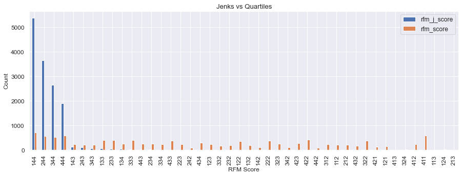

```python
# Visualize the result
df = merchant['rfm_j_score'].value_counts().to_frame().join(merchant['rfm_score'].value_counts())
ax = df.plot(kind='bar', title ="Jenks vs Quartiles", figsize=(15, 5), legend=True, fontsize=12)
ax.set_xlabel("RFM Score", fontsize=12)
ax.set_ylabel("Count", fontsize=12)
plt.show()
```

The result of Jenks rfm score is as same as Quartile as the largest segment that is made up of recent users but are not frequent and not spend much.

The rest are very different. Jenks categorizes the next three largest segments are all low value customers

Even though the partitions of Jenks Natural Break method looks better than Quartile, it can't detect the segment with high monetary and frequency. Therefore, we should move forward with just quartile RFM score

## Train K-Means Clustering Model

### Preprocessing data

For K-Means Clustering, we need to either standardize or normalize our data

#### Looking at the data again

```python
merchant[['recency','frequency','monetary']]
```

|  | recency | frequency | monetary |
| --- | --- | --- | --- |
| 0 | 256 | 25507 | 20907471 |
| 1 | 165 | 12178 | 60733740 |
| 2 | 210 | 12042 | 41443545 |
| 3 | 45 | 11969 | 18054500 |
| 4 | 719 | 11191 | 150931806 |
| ... | ... | ... | ... |
| 14346 | 719 | 1 | 93980 |
| 14347 | 292 | 1 | 23906 |
| 14348 | 723 | 1 | 48197 |
| 14349 | 685 | 1 | 17536 |
| 14350 | 125 | 1 | 2068 |

14351 rows × 3 columns

```python
rfm.describe()
```

|  | recency | frequency | monetary |
| --- | --- | --- | --- |
| count | 14351.00 | 14351.00 | 14351.00 |
| mean | 234.83 | 105.46 | 1632885.22 |
| std | 189.35 | 527.57 | 6419706.45 |
| min | 1.00 | 1.00 | 201.00 |
| 25% | 71.00 | 3.00 | 36263.00 |
| 50% | 190.00 | 11.00 | 160262.00 |
| 75% | 364.00 | 45.00 | 823099.50 |
| max | 729.00 | 25507.00 | 233045139.00 |

#### Feature Scaling/ Standardizing

We notice features 'recency','frequency' and 'monetary' have different scales and have large variability, which is clearly shown by the mean and std of each feature.

Before training machine learning models, standardization is an important step of data preprocessing. It controls the variability of the dataset, it convert data into specific range using a linear transformation which generate good quality clusters and improve the accuracy

We standardize the features so that they are centered around 0 with a standard deviation of 1

In K-means clustering analyses, standardization is especially crucial in order to compare similarities between features based on certain distance measures.

#### Standardizing features

```python
from sklearn import preprocessing

std_scale = preprocessing.StandardScaler().fit(merchant[['recency','frequency','monetary']])

df_std = merchant[['recency','frequency','monetary']]
df_std[['recency','frequency','monetary']] = std_scale.transform(df_std[['recency','frequency','monetary']])
df_std
```

|  | recency | frequency | monetary |
| --- | --- | --- | --- |
| 0 | 0.11 | 48.15 | 3.00 |
| 1 | -0.37 | 22.88 | 9.21 |
| 2 | -0.13 | 22.63 | 6.20 |
| 3 | -1.00 | 22.49 | 2.56 |
| 4 | 2.56 | 21.01 | 23.26 |
| ... | ... | ... | ... |
| 14346 | 2.56 | -0.20 | -0.24 |
| 14347 | 0.30 | -0.20 | -0.25 |
| 14348 | 2.58 | -0.20 | -0.25 |
| 14349 | 2.38 | -0.20 | -0.25 |
| 14350 | -0.58 | -0.20 | -0.25 |

14351 rows × 3 columns

#### Train the model

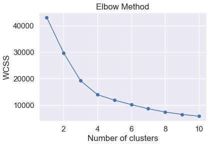

```python
# Identify the optimal number of clusters
wcss = []
for i in range(1, 11):
    kmeans = KMeans(n_clusters=i, init='k-means++', max_iter=300, n_init=10, random_state=0)
    kmeans.fit(df_std)
    wcss.append(kmeans.inertia_)
plt.plot(range(1, 11), wcss, marker='o')
plt.title('Elbow Method')
plt.xlabel('Number of clusters')
plt.ylabel('WCSS')
plt.show()
```

```python
# Duplicate merchant 2
merchant2 = merchant
```

```python
# Fit the K-means model
kmeans = KMeans(n_clusters=4)
kmeans.fit(df_std)
merchant2['K_Cluster'] = pd.Series(kmeans.labels_, index=merchant.index)
merchant2
```

[output not shown]

14351 rows × 15 columns

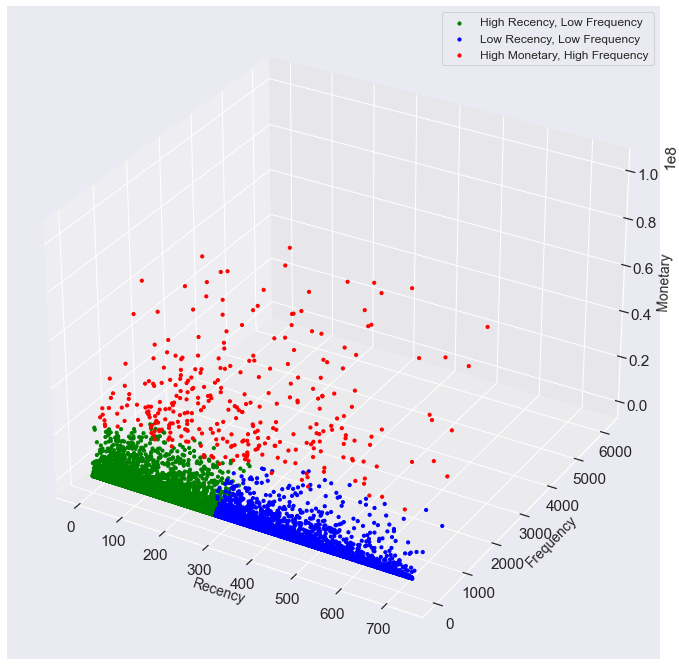

```python
# Visualize the result
from mpl_toolkits.mplot3d import Axes3D
import matplotlib.colors as mcolors
fig = plt.figure(figsize=(18,12))
dx = fig.add_subplot(111, projection='3d')
colors = ['green', 'blue', 'red', 'yellow', 'black']
mapping = {0:'High Recency, Low Frequency', 1:'Low Recency, Low Frequency', 2:'High Monetary, High Frequency'}
dx = fig.add_subplot(111, projection='3d')
for i in range(0,len(merchant2['K_Cluster'].unique())-1):
    dx.scatter(merchant2[merchant2.K_Cluster == i].recency,
               merchant2[merchant2.K_Cluster == i].frequency,
               merchant2[merchant2.K_Cluster == i].monetary,
               c = colors[i],
               label = mapping[i],
               s=10, alpha=1.0)
dx.set_xlabel('Recency', fontsize=14)
dx.set_ylabel('Frequency', fontsize=14)
dx.set_zlabel('Monetary', fontsize=14)
dx.legend(fontsize=12)
```

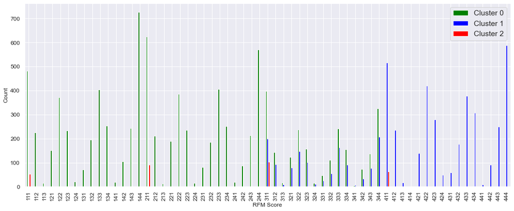

```python
# Match K-means clusters with RFM segments
myDict = {}
for i in range(0, len(merchant2['K_Cluster'].unique())-1):
    clust = merchant[merchant2['K_Cluster'] == i]
    myDict["Cluster " + str(i)] = clust['rfm_score'].value_counts()
df = pd.DataFrame.from_dict(myDict)
colors = ['green', 'blue', 'red', 'yellow']
ax = df.plot(kind='bar', figsize=(18, 7), legend=True, fontsize=12, color=colors)
ax.set_xlabel("RFM Score", fontsize=12)
ax.set_ylabel("Count", fontsize=12)
plt.show()
```

The clusters are consistent with RFM segments

The model can cluster recency, and frequency. Let's try another model to cluster monetary and frequency.

Visualize data distribution of features (independent variables)

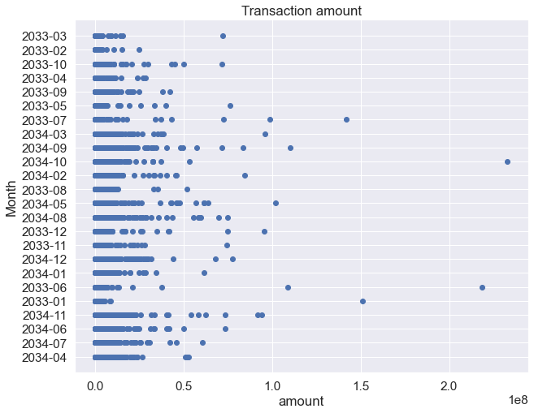

```python
# Scatter plots
plt.subplots(figsize = (10,8))
plt.scatter(merchant['monetary'],merchant['month'])
plt.title('Transaction amount')
plt.xlabel('amount')
plt.ylabel('Month')
# To show the plot
plt.show()
```

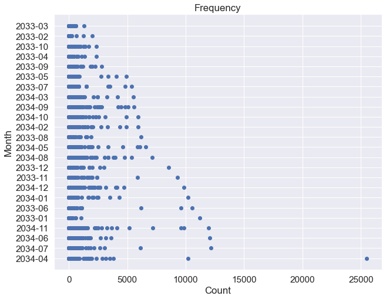

```python
# Scatter plots
plt.subplots(figsize = (10,8))
plt.scatter(merchant['frequency'],merchant['month'])
plt.title('Frequency')
plt.xlabel('Count')
plt.ylabel('Month')
# To show the plot
plt.show()
```

## Train Clustering Model: HDBSCAN

HDBSCAN extends DBSCAN by converting it into a hierarchical clustering algorithm, and then using a technique to extract a flat clustering based in the stability of clusters.

Here we use unstandardized features/ raw data so that the model can capture most of the data points

```python
# Train HDBSCAN model
import hdbscan
clusterer = hdbscan.HDBSCAN(min_cluster_size=400,min_samples=12, metric='euclidean')
clusterer.fit(merchant[['recency','frequency','monetary']])
merchant['HDB_Cluster'] = pd.Series(clusterer.labels_, index=rfm.index)
```

```python
merchant
```

|  | merchant | frequency | monetary | month | last_transaction_date | recency | r_percentile | r_score | f_percentile | f_score | m_percentile | m_score | rfm_score | K_Cluster | HDB_Cluster |
| --- | --- | --- | --- | --- | --- | --- | --- | --- | --- | --- | --- | --- | --- | --- | --- |
| 0 | 5608f200cf | 25507 | 20907471 | 2034-04 | 2034-04-20 | 256 | 0.39 | 3 | 1.00 | 1 | 0.99 | 1 | 311 | 1 | -1 |
| 1 | 53b3fbeae2 | 12178 | 60733740 | 2034-07 | 2034-07-20 | 165 | 0.54 | 2 | 1.00 | 1 | 1.00 | 1 | 211 | 1 | -1 |
| 2 | 1ddaea9838 | 12042 | 41443545 | 2034-06 | 2034-06-05 | 210 | 0.47 | 3 | 1.00 | 1 | 1.00 | 1 | 311 | 1 | -1 |
| 3 | 89e2d29885 | 11969 | 18054500 | 2034-11 | 2034-11-17 | 45 | 0.82 | 1 | 1.00 | 1 | 0.98 | 1 | 111 | 1 | -1 |
| 4 | 654930c922 | 11191 | 150931806 | 2033-01 | 2033-01-12 | 719 | 0.00 | 4 | 1.00 | 1 | 1.00 | 1 | 411 | 1 | -1 |
| ... | ... | ... | ... | ... | ... | ... | ... | ... | ... | ... | ... | ... | ... | ... | ... |
| 14346 | 3839c43c25 | 1 | 93980 | 2033-01 | 2033-01-12 | 719 | 0.00 | 4 | 0.06 | 4 | 0.41 | 3 | 443 | 2 | 2 |
| 14347 | 5cdc7cd9f5 | 1 | 23906 | 2034-03 | 2034-03-15 | 292 | 0.34 | 3 | 0.06 | 4 | 0.18 | 4 | 344 | 2 | 2 |
| 14348 | 1718d01b43 | 1 | 48197 | 2033-01 | 2033-01-08 | 723 | 0.00 | 4 | 0.06 | 4 | 0.30 | 3 | 443 | 2 | 2 |
| 14349 | 4cf644502f | 1 | 17536 | 2033-02 | 2033-02-15 | 685 | 0.01 | 4 | 0.06 | 4 | 0.14 | 4 | 444 | 2 | 2 |
| 14350 | 314ea3d710 | 1 | 2068 | 2034-08 | 2034-08-29 | 125 | 0.62 | 2 | 0.06 | 4 | 0.01 | 4 | 244 | 0 | 2 |

14351 rows × 15 columns

Here we can better visualize clusters by different levels of frequency and monetary The clusters look better with this model as it captures the data points on both low and high value of each criteria (recency, frequency, monetary) Cluster -1 is excluded, since it is noise.

Based on the graph, we can rename the clusters to provide more clarity for the segments. The clusters are spread over all recency levels so it can only classfiy different levels of monetary and frequency value.

- Cluster 0 (green): High monetary and frequency
- Cluster 1 (blue): Average monetary and frequency
- Cluster 2 (red): Low monetary and frequency

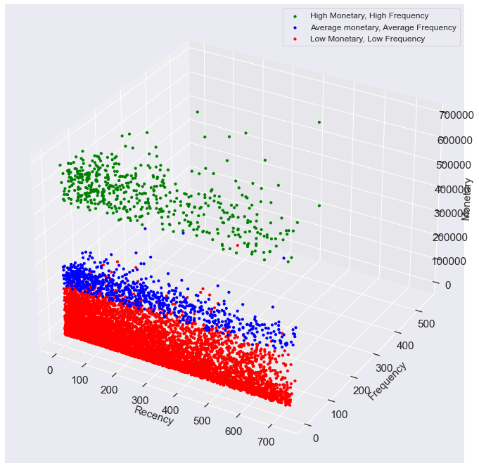

```python
# Visualize the result
from mpl_toolkits.mplot3d import Axes3D
import matplotlib.colors as mcolors
fig = plt.figure(figsize=(18,12))
mapping = {0:'High Monetary, High Frequency', 1:'Average monetary, Average Frequency', 2:'Low Monetary, Low Frequency'}
dx = fig.add_subplot(111, projection='3d')
colors = ['green', 'blue', 'red', 'yellow', 'black']
for i in range(0,len(merchant['HDB_Cluster'].unique())-1):
    dx.scatter(merchant[merchant.HDB_Cluster == i].recency,
               merchant[merchant.HDB_Cluster == i].frequency,
               merchant[merchant.HDB_Cluster == i].monetary,
               c = colors[i],
               label = mapping[i],
               s=10, alpha=1.0)
dx.set_xlabel('Recency', fontsize=15)
dx.set_ylabel('Frequency', fontsize=15)
dx.set_zlabel('Monetary', fontsize=15)
dx.legend(fontsize=12)
```

```python
pd.Series(clusterer.labels_).value_counts()
```

```
 2    7687
-1    5365
 1     792
 0     507
dtype: int64
```

```python
# Summary statistics of the cluster. Cluster -1 is excluded, since it is noise.
myDict = {}
for i in range(0, len(merchant['HDB_Cluster'].unique())-1):
    clust = merchant[merchant['HDB_Cluster'] == i]
    myDict['Cluster ' + str(i)] = [int(round(clust['recency'].mean(),0)),
                            int(round(clust['frequency'].mean(),0)),
                            int(round(clust['monetary'].mean(),0)),
                            int(round(clust['recency'].median(),0)),
                            int(round(clust['frequency'].median(),0)),
                            int(round(clust['monetary'].median(),0))]

stat = pd.DataFrame.from_dict(myDict, orient='index',
                            columns=['mean_Recency','mean_Frequency', 'mean_Monetary',
                                    'median_Recency','median_Frequency', 'median_Monetary'])
stat
```

|  | mean_Recency | mean_Frequency | mean_Monetary | median_Recency | median_Frequency | median_Monetary |
| --- | --- | --- | --- | --- | --- | --- |
| Cluster 0 | 235 | 54 | 603809 | 179 | 36 | 600421 |
| Cluster 1 | 246 | 24 | 237526 | 208 | 17 | 235440 |
| Cluster 2 | 237 | 8 | 58825 | 189 | 4 | 40400 |

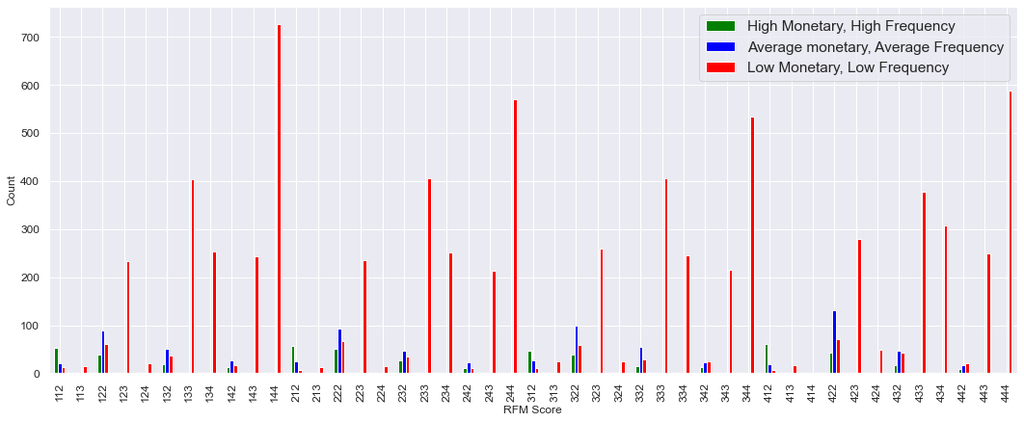

```python
# Match the clusters with rfm_score
mapping = {0:'High Monetary, High Frequency', 1:'Average monetary, Average Frequency', 2:'Low Monetary, Low Frequency'}
myDict = {}
for i in range(0, len(merchant['HDB_Cluster'].unique())-1):
    clust = merchant[merchant['HDB_Cluster'] == i]
    myDict[mapping[i]] = clust['rfm_score'].value_counts()
df = pd.DataFrame.from_dict(myDict)
colors = ['green', 'blue', 'red', 'yellow']
ax = df.plot(kind='bar', figsize=(18, 7), legend=True, fontsize=12, color=colors)
ax.set_xlabel("RFM Score", fontsize=12)
ax.set_ylabel("Count", fontsize=12)
plt.show()
```

The clustering model has consistent results with RFM Score Segmentation.

Now we know that K-Means clustering model is not useful. We might drop related columns to clean the data

```python
# Drop columns to reduce noise
merchant.drop(['r_j_score','f_j_score','m_j_score','rfm_j_score','r_percentile','f_percentile','m_percentile'], axis=1, inplace=True)
```

# Problem 2: Detect and Predict Churn

## 1. Identify churn

Churn are merchants that have recency more than 30 days Churn is dummy variable, 1 is churn, 0 is active users

```python
# Create churn column
merchant['churn'] = np.where(merchant['recency']>30,1,0)
merchant.tail(10)
```

|  | merchant | frequency | monetary | month | last_transaction_date | recency | r_score | f_score | m_score | rfm_score | K_Cluster | HDB_Cluster | churn |
| --- | --- | --- | --- | --- | --- | --- | --- | --- | --- | --- | --- | --- | --- |
| 14341 | 637c3901b9 | 1 | 59068 | 2033-10 | 2033-10-24 | 434 | 4 | 4 | 3 | 443 | 1 | 2 | 1 |
| 14342 | e6ef86289b | 1 | 901486 | 2034-12 | 2034-12-26 | 6 | 1 | 4 | 1 | 141 | 0 | -1 | 0 |
| 14343 | 86f216bd1a | 1 | 109966 | 2033-07 | 2033-07-19 | 531 | 4 | 4 | 3 | 443 | 1 | 2 | 1 |
| 14344 | 9162c065c3 | 1 | 513096 | 2034-11 | 2034-11-22 | 40 | 1 | 4 | 2 | 142 | 0 | -1 | 1 |
| 14345 | dcb392770a | 1 | 3398 | 2034-12 | 2034-12-14 | 18 | 1 | 4 | 4 | 144 | 0 | 2 | 0 |
| 14346 | 3839c43c25 | 1 | 93980 | 2033-01 | 2033-01-12 | 719 | 4 | 4 | 3 | 443 | 1 | 2 | 1 |
| 14347 | 5cdc7cd9f5 | 1 | 23906 | 2034-03 | 2034-03-15 | 292 | 3 | 4 | 4 | 344 | 1 | 2 | 1 |
| 14348 | 1718d01b43 | 1 | 48197 | 2033-01 | 2033-01-08 | 723 | 4 | 4 | 3 | 443 | 1 | 2 | 1 |
| 14349 | 4cf644502f | 1 | 17536 | 2033-02 | 2033-02-15 | 685 | 4 | 4 | 4 | 444 | 1 | 2 | 1 |
| 14350 | 314ea3d710 | 1 | 2068 | 2034-08 | 2034-08-29 | 125 | 2 | 4 | 4 | 244 | 0 | 2 | 1 |

## 2. Resampling before training the model

Before training the model, we begin with resampling the data set so that the churn class will be rebalanced and better for machine learning models.

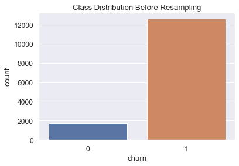

```python
# Plot the class of churn
sns.countplot('churn', data=merchant).set_title('Class Distribution Before Resampling')
```

```python
#Separating positive class (churn=yes) and negative class (churn=no):
churn_no = merchant[merchant.churn == 0]
churn_yes = merchant[merchant.churn == 1]

#Upsampling the positive class:
churn_yes_upsampled = churn_yes.sample(n=len(churn_no), replace=True, random_state=42)
print(len(churn_yes_upsampled))
```

```
1730
```

#### Combining positive and negative class and checking class distribution:

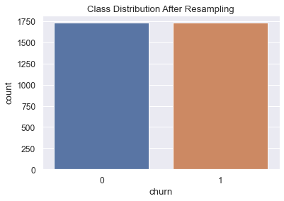

```python
merchant_upsampled = churn_no.append(churn_yes_upsampled).reset_index(drop=True)
sns.countplot('churn', data=merchant_upsampled).set_title('Class Distribution After Resampling')
```

```python
merchant_upsampled
```

|  | merchant | frequency | monetary | recency | r_score | f_score | m_score | rfm_score | HDB_Cluster | churn |
| --- | --- | --- | --- | --- | --- | --- | --- | --- | --- | --- |
| 0 | 00575c7901 | 9860 | 67935727 | 22 | 1 | 1 | 1 | 111 | -1 | 0 |
| 1 | 71a3c03fc8 | 4707 | 77722861 | 21 | 1 | 1 | 1 | 111 | -1 | 0 |
| 2 | 9843e52410 | 4129 | 23668716 | 4 | 1 | 1 | 1 | 111 | -1 | 0 |
| 3 | 93711f0256 | 4031 | 43973452 | 9 | 1 | 1 | 1 | 111 | -1 | 0 |
| 4 | ffb94e1865 | 3140 | 25565792 | 19 | 1 | 1 | 1 | 111 | -1 | 0 |
| ... | ... | ... | ... | ... | ... | ... | ... | ... | ... | ... |
| 3455 | 229364d822 | 7 | 15440 | 339 | 3 | 3 | 4 | 334 | 2 | 1 |
| 3456 | 3fdd98b21a | 1 | 102664 | 385 | 4 | 4 | 3 | 443 | 2 | 1 |
| 3457 | dbff881fcd | 5 | 41784 | 329 | 3 | 3 | 3 | 333 | 2 | 1 |
| 3458 | 938b8741ed | 110 | 595759 | 237 | 3 | 1 | 2 | 312 | 0 | 1 |
| 3459 | 98a5c29f10 | 6 | 95837 | 63 | 1 | 3 | 3 | 133 | 2 | 1 |

3460 rows × 10 columns

Now we have a sample of 3460 rows from the orginal merchant dataset

#### We need to make sure that the values of RFM in the sample are not varied significantly from the original dataset

```python
# Compare RFM of the sample and the original data
sample = merchant_upsampled[['recency','frequency','monetary','churn']].groupby('churn').mean()
original = merchant[['recency','frequency','monetary','churn']].groupby('churn').mean()

comp = pd.concat([sample, original], axis=1)

comp
```

| churn | recency | frequency | monetary | recency | frequency | monetary |
| --- | --- | --- | --- | --- | --- | --- |
| 0 | 16.28 | 73.67 | 1135810.93 | 16.28 | 73.67 | 1135810.93 |
| 1 | 268.18 | 102.81 | 1740998.94 | 264.79 | 109.82 | 1701020.75 |

The mean of recency, frequency, monetary of these datasets are very similar Now we are ready to train the model

## 3. Train model

Logistic Regression is not sensitive to the magnitude of variables. So standardization is not needed before fitting this kind of models.

The performance of logistic regression did not improve with data scaling. If there predictor variables with large ranges that do not effect the target variable, a regression algorithm will make the corresponding coefficients ai small so that they do not effect predictions so much.

Therefore, we will use the original merchant data to train the model

### Logistic Regression

```python
# Import libraries
from sklearn.datasets import make_blobs
from sklearn.model_selection import RepeatedStratifiedKFold
from sklearn.model_selection import GridSearchCV
from sklearn.linear_model import LogisticRegression
```

```python
# Change data type of rfm_score
merchant['rfm_score'] = merchant['rfm_score'].astype('category')
merchant_upsampled['rfm_score'] = merchant_upsampled['rfm_score'].astype('category')
```

```python
# Import library and assign values for x,y
# drop merchant column from x_train
from sklearn.model_selection import train_test_split
x = merchant_upsampled.drop(['churn','merchant','rfm_score','HDB_Cluster'], axis=1) #features (independent variables)
y = merchant_upsampled['churn'] #target (dependent variable)
```

```python
# Dividing dataset into train and test subsets:
x_train, x_test, y_train, y_test = train_test_split(x, y, test_size = 0.2, random_state=42)
```

```python
# Logistic regression
from sklearn.linear_model import LogisticRegression
from sklearn import metrics
logmodel=LogisticRegression()
logmodel.fit(x_train,y_train)
prediction=logmodel.predict(x_test)


# Make predictions
y_train_pred = logmodel.predict(x_train)
y_test_pred = logmodel.predict(x_test)
```

#### Evaluate the model

Using accuracy, precision and recall When choosing from the many models out there to use to predict enterprise churn simple accuracy won’t show the whole picture. Enterprise churn should be under 25%, so simple accuracy isn’t the whole picture. A model that says “no one will churn” will be 75% accurate. So we need to focus on precision and recall.

Precision is the % of all churn that the model correctly identifies Recall is the % of identified churn that actually ends up churning These evaluate false positives, which lead to unnecessary and costly churn prevention efforts, and false negatives, which lead to companies churning without being identified.

```python
# Accuracy of test data
accuracy = metrics.accuracy_score(y_test, y_test_pred)
```

```python
# Precision
precision = metrics.precision_score(y_test, y_test_pred)
```

```python
# Recall
recall = metrics.recall_score(y_test, y_test_pred)
```

```python
e = {'accuracy':accuracy, 'precision':precision,'recall':recall}
e
```

```
{'accuracy': 0.5158959537572254,
 'precision': 0.4915514592933948,
 'recall': 0.9876543209876543}
```

The accuracy and precision of the model are relatively low. We need to improve the model. This could be conducted by many ways such as feature selection or hyperameter tuning.

In this case, as the churn variable is created soldly based on recency, feature selection will choose recency as the best predictor. However, as the goal of the project is to predict which active user (recency <30) will likely to churn in the future, this model will be unable to do the job.

Therefore, I choose to go with hyperparameter tuning.

The correlation matrix and the graph below proves my hypothesis. There is only a high correlation between churn and recency. Monetary and frequency are not ideal predictors of churn.

```python
# Explore the relationship among features and target variable
merchant_upsampled.corr()
```

|  | frequency | monetary | recency | HDB_Cluster | churn |
| --- | --- | --- | --- | --- | --- |
| frequency | 1.00 | 0.81 | 0.04 | -0.22 | 0.03 |
| monetary | 0.81 | 1.00 | 0.06 | -0.29 | 0.05 |
| recency | 0.04 | 0.06 | 1.00 | -0.03 | 0.69 |
| HDB_Cluster | -0.22 | -0.29 | -0.03 | 1.00 | -0.05 |
| churn | 0.03 | 0.05 | 0.69 | -0.05 | 1.00 |

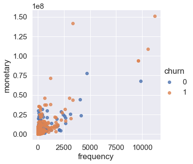

```python
# Explore the relationship between churn and frequency, monetary
sns.lmplot(x='frequency', y='monetary', data=merchant_upsampled, hue='churn', fit_reg=False)
```

## 4. Improve the model

### Using hyperparameter tuning

```python
# define models and parameters
solvers = ['newton-cg', 'lbfgs', 'liblinear']
penalty = ['l2']
c_values = [100, 10, 1.0, 0.1, 0.01]
# define grid search
grid = dict(solver=solvers,penalty=penalty,C=c_values)
cv = RepeatedStratifiedKFold(n_splits=10, n_repeats=10, random_state=1)
grid_search = GridSearchCV(estimator=logmodel, param_grid=grid, n_jobs=-1, cv=cv, scoring='accuracy',error_score=0)
grid_result = grid_search.fit(x_train, y_train)
```

```python
# summarize results
# best accuracy
grid_result.best_score_
```

```
0.9792872216118175
```

```python
# best parameters
grid_result.best_params_
```

```
{'C': 0.01, 'penalty': 'l2', 'solver': 'newton-cg'}
```

```python
# Apply the parameters above to the model
logmodel2=LogisticRegression(C= 0.01, penalty= 'l2', solver='newton-cg')
logmodel2.fit(x_train,y_train)
prediction=logmodel2.predict(x_test)

# Evaluate the model. Here we use accuracy
y_train_pred = logmodel2.predict(x_train)
y_test_pred = logmodel2.predict(x_test)

# Accuracy of test data
accuracy_test = accuracy_score(y_test, y_test_pred)
accuracy_train = accuracy_score(y_train, y_train_pred)
precision = metrics.precision_score(y_test, y_test_pred)
recall = metrics.recall_score(y_test, y_test_pred)
print('Accuracy:',accuracy_test)
print('Precision:',precision)
print('Recall:', recall)
```

```
Accuracy: 0.9754335260115607
Precision: 0.9967637540453075
Recall: 0.9506172839506173
```

Now we can start to use this model to predict the active data set

## 5. Predict which active user will churn in the future

```python
active = merchant[merchant['churn']==0]
y_active = active['churn']
x_active = active.drop(['churn','merchant','rfm_score','HDB_Cluster','K_Cluster','month','last_transaction_date'], axis=1)
x_active
```

|  | frequency | monetary | recency | r_score | f_score | m_score |
| --- | --- | --- | --- | --- | --- | --- |
| 9 | 9860 | 67935727 | 22 | 1 | 1 | 1 |
| 37 | 4707 | 77722861 | 21 | 1 | 1 | 1 |
| 45 | 4129 | 23668716 | 4 | 1 | 1 | 1 |
| 47 | 4031 | 43973452 | 9 | 1 | 1 | 1 |
| 65 | 3140 | 25565792 | 19 | 1 | 1 | 1 |
| ... | ... | ... | ... | ... | ... | ... |
| 14329 | 1 | 23567 | 17 | 1 | 4 | 4 |
| 14334 | 1 | 45561 | 19 | 1 | 4 | 3 |
| 14340 | 1 | 43189 | 4 | 1 | 4 | 3 |
| 14342 | 1 | 901486 | 6 | 1 | 4 | 1 |
| 14345 | 1 | 3398 | 18 | 1 | 4 | 4 |

1730 rows × 6 columns

```python
# Fit the estimator using the new feature subset
# and make a prediction on the active users
active['churn_pred']=logmodel2.predict(x_active)
```

#### List of predicted churn from active user data

```python
active[active['churn_pred']==1]
```

|  | merchant | frequency | monetary | month | last_transaction_date | recency | r_score | f_score | m_score | rfm_score | K_Cluster | HDB_Cluster | churn | churn_pred |
| --- | --- | --- | --- | --- | --- | --- | --- | --- | --- | --- | --- | --- | --- | --- |
| 1497 | f1dac61590 | 167 | 890080 | 2034-12 | 2034-12-02 | 30 | 1 | 1 | 1 | 111 | 0 | -1 | 0 | 1 |
| 1678 | aedcc213a5 | 141 | 1782945 | 2034-12 | 2034-12-02 | 30 | 1 | 1 | 1 | 111 | 0 | -1 | 0 | 1 |
| 1820 | 487bb338df | 128 | 1897774 | 2034-12 | 2034-12-02 | 30 | 1 | 1 | 1 | 111 | 0 | -1 | 0 | 1 |
| 1903 | 0c43e8ca9c | 121 | 1134116 | 2034-12 | 2034-12-02 | 30 | 1 | 1 | 1 | 111 | 0 | -1 | 0 | 1 |
| 2382 | 8b15da3ecd | 88 | 1774166 | 2034-12 | 2034-12-02 | 30 | 1 | 1 | 1 | 111 | 0 | -1 | 0 | 1 |
| 2697 | b1220d7962 | 75 | 879892 | 2034-12 | 2034-12-04 | 28 | 1 | 1 | 1 | 111 | 0 | -1 | 0 | 1 |
| 3353 | 61b5030d9b | 50 | 260651 | 2034-12 | 2034-12-02 | 30 | 1 | 1 | 2 | 112 | 0 | 1 | 0 | 1 |
| 3484 | 3c781e3803 | 47 | 1179895 | 2034-12 | 2034-12-03 | 29 | 1 | 1 | 1 | 111 | 0 | -1 | 0 | 1 |